# Diving into the data of the Tox24 Challenge

```r
library("tidyverse")
library("readxl")
library("ggplot2")
library("M3C")
library("VennDiagram")
library("caret")
library("ggVennDiagram")
```

# Load the data

Get the data provided on the Challenge website for training and testing.

```r
challenge_data <- rbind(
  read_csv(file = "/data/bioinf/projects/data/2022_deepFPlearn/input_datasets/tox24_challenge/tox24_challenge_train.csv") %>%
    mutate("origin" = "train"),
  read_csv(file = "/data/bioinf/projects/data/2022_deepFPlearn/input_datasets/tox24_challenge/tox24_challenge_test.csv") %>%
    mutate("activity" = NA, "origin" = "test")
)
challenge_data %>% group_by(origin) %>% tally()
```

| origin | n |
| --- | --- |
| test | 500 |
| train | 1012 |

Any NAs in the feature space?

```r
challenge_data %>% filter(is.na(SMILES))
```

| SMILES | activity | origin |
| --- | --- | --- |

No. Any duplicated features here?

```r
challenge_data_dupl_smiles <- challenge_data$SMILES[duplicated(challenge_data$SMILES)]
challenge_data %>% filter(SMILES %in% challenge_data_dupl_smiles)
```

| SMILES | activity | origin |
| --- | --- | --- |
| COCCOCCO | 10.3 | train |
| COCCOCCO | -5.3 | train |

Yes, with two different `activity` values. Keep this in mind

There are `1012` substances with activity for training (incl. duplicated SMILES).

Load the data from the supplementary information of the Transthyretin paper to get more information about the substances and the experimental setup: https://chemrxiv.org/engage/chemrxiv/article-details/664cab3b91aefa6ce1976a1e

```r
supp_data_s4 <- read_excel(
  path = "/data/bioinf/projects/data/2022_deepFPlearn/input_datasets/tox24_challenge/ttr-supplemental-tables.xlsx",
  sheet = 6) %>%
  rename("activity" = "Median % activity")
supp_data_s4 %>%
  mutate("has_SMILES" = !is.na(SMILES)) %>%
  group_by(dataset, has_SMILES) %>%
  tally()
```

| dataset | has_SMILES | n |
| --- | --- | --- |
| blind test | TRUE | 300 |
| leaderboard | TRUE | 200 |
| training | FALSE | 48 |
| training | TRUE | 964 |

There are again `1012` substances associated to the *training* dataset.

Any NAs in the feature space, that have an `activity` and are part of the training set, here?

```r
supp_data_s4_no_smiles <- supp_data_s4 %>%
  filter(is.na(SMILES), !is.na(activity), dataset == "training")
supp_data_s4_no_smiles %>% nrow()
```

```
[1] 48
```

Yes! No idea (so far) to which SMILES in the challenge data they could belong. We may resolve this by comparing the activity values, but we don’t do this for now.

There have to be some SMILES from the challenge dataset which are not part of the supplementary material.

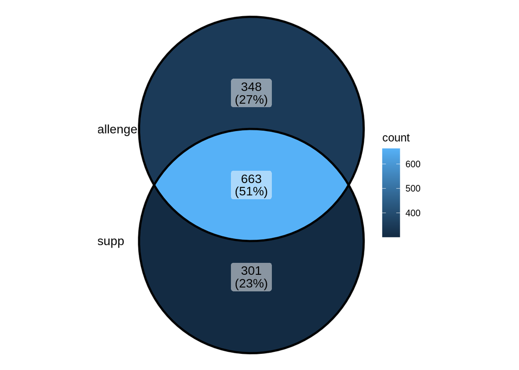

```r
supp_data_s4_smiles_train <- supp_data_s4 %>%
  filter(!is.na(SMILES), dataset == "training", !is.na("Median % activity")) %>%
  drop_na() %>%
  pull(SMILES)
challenge_data_smiles_train <- challenge_data %>%
  filter(origin == "train") %>%
  drop_na() %>%
  pull(SMILES) %>%
  unique()
ggVennDiagram(x = list("supp" = supp_data_s4_smiles_train,
                       "challenge" = challenge_data_smiles_train))
```

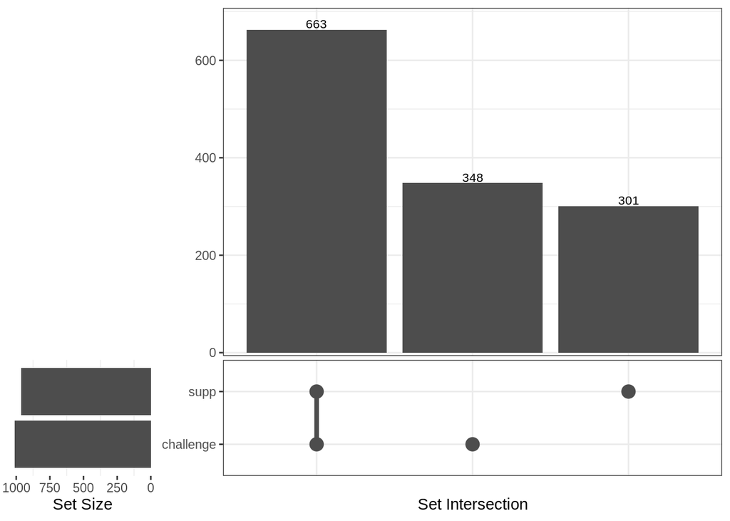

```r
ggVennDiagram(x = list("supp" = supp_data_s4_smiles_train,
                       "challenge" = challenge_data_smiles_train), force_upset = TRUE)
```

It is very strange that the total numbers 1012 substances for training, 500 for testing (300 + 200) are correct, but the SMILES don’t fit between the datasets.

For now, proceed with the Challenge data and ignore this fact.

Load the fingerprints for the train and test data

```r
challenge_data_fp <- rbind(
  read_csv(file = "/data/bioinf/projects/data/2022_deepFPlearn/input_datasets/tox24_challenge/tox24_challenge_train_fp.csv") %>%
    mutate("origin" = "train"),
  read_csv(file = "/data/bioinf/projects/data/2022_deepFPlearn/input_datasets/tox24_challenge/tox24_challenge_test_fp.csv") %>%
    mutate("activity" = NA, "origin" = "test")
)
```

Any NAs for the fingerprints?

```r
challenge_data_fp %>% filter(is.na(fp_0))
```

| SMILES | activity | fp_0 | fp_1 | fp_2 | fp_3 | fp_4 | fp_5 | fp_6 | fp_7 | fp_8 | fp_9 | fp_10 | fp_11 | fp_12 | fp_13 | fp_14 | fp_15 | fp_16 | fp_17 | fp_18 | fp_19 | fp_20 | fp_21 | fp_22 | fp_23 | fp_24 | fp_25 | fp_26 | fp_27 | … |
| --- | --- | --- | --- | --- | --- | --- | --- | --- | --- | --- | --- | --- | --- | --- | --- | --- | --- | --- | --- | --- | --- | --- | --- | --- | --- | --- | --- | --- | --- | --- |

No!

## Action 1 - rm duplicated entry

```r
supp_data_s4 %>% filter(SMILES %in% challenge_data_dupl_smiles)
```

| DTXSID | Chemical | CASRN | SMILES | Library | Max conc | activity | Tested in CR? | dataset |
| --- | --- | --- | --- | --- | --- | --- | --- | --- |
| DTXSID3025049 | Diethylene glycol monomethyl ether | 111-77-3 | COCCOCCO | ph2 | 100 | 10.32023 | N | training |

```r
challenge_data_fp %>%
  filter(SMILES %in% challenge_data_dupl_smiles) %>%
  select(-starts_with("fp_"))
```

| SMILES | activity | origin |
| --- | --- | --- |
| COCCOCCO | 10.3 | train |
| COCCOCCO | -5.3 | train |

Discard the second entry, since the probably true value is the one from the publication.

```r
challenge_data_fp <- challenge_data_fp %>%
  filter(!(SMILES %in% challenge_data_dupl_smiles & activity < 0))
```

## Distribution of target values

```r
challenge_data_fp$activity %>% summary()
```

```
   Min. 1st Qu.  Median    Mean 3rd Qu.    Max.    NA's
 -45.00   11.10   30.00   40.86   73.40  111.10     500
```

**Observations:**

- the 500 NA’s are the test values for which we don’t have an activity yet
- there are negative values and values > 100 for a column representing `Median % activity`

I discussed the paper and those values with Charlie and found a potential categorization:

```r
challenge_data_fp <- challenge_data_fp %>%
  mutate("range" = ifelse(activity < -20,
                          yes = "very_strong_binding",
                          no = ifelse(between(activity, -20, 0),
                                      yes = "low_moderate_binding",
                                      no = ifelse(between(activity, 0, 20),
                                                  yes = "no_minimal_binding",
                                                  no = ifelse(between(activity, 20, 85),
                                                              yes = "moderate_strong_binding",
                                                              no = ifelse(activity > 100, yes = "over_binding_or_artifact",
                                                                          no = "strong_binding")))))) %>%
  select(SMILES, activity, origin, range, starts_with("fp_")) %>%
  arrange(origin) %>%
  mutate("range" = factor(range, levels = c("very_strong_binding", "low_moderate_binding", "no_minimal_binding",
                                            "moderate_strong_binding", "strong_binding", "over_binding_or_artifact")))
```

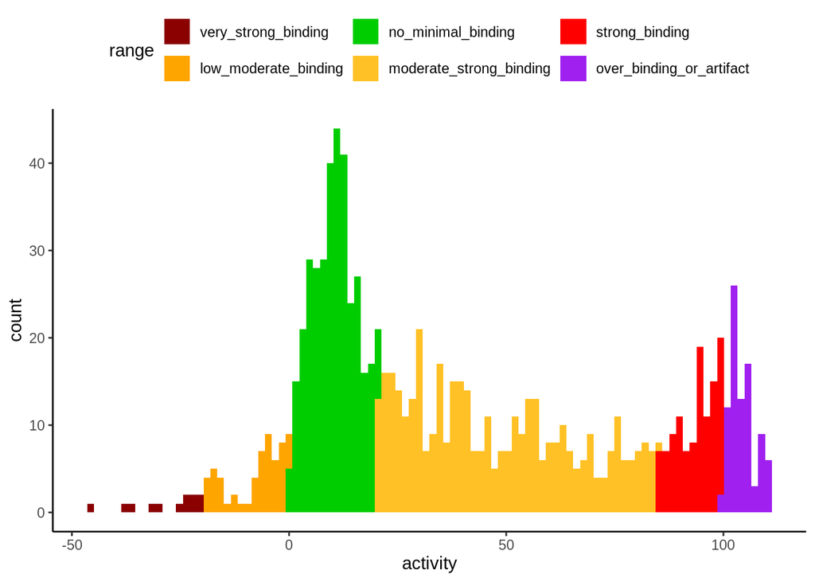

```r
ggplot(data = challenge_data_fp %>%
  filter(origin == "train") %>%
  select(activity, range),
       aes(x = activity, fill = range)) +
  geom_histogram(bins = 100) +
  scale_fill_manual(values = c("darkred", "orange", "green3", "goldenrod1", "red", "purple")) +
  theme_classic() +
  theme(
    legend.position = "top"
  )
```

Perform a linear min-max scaling to 0-1 for the regression

```r
process <- preProcess(x = challenge_data_fp %>%
  filter(origin == "train") %>%
  select(activity), method = "range")
challenge_data_fp <- challenge_data_fp %>%
  mutate("activity_scaled" = predict(process, challenge_data_fp %>% select(activity))$activity)
```

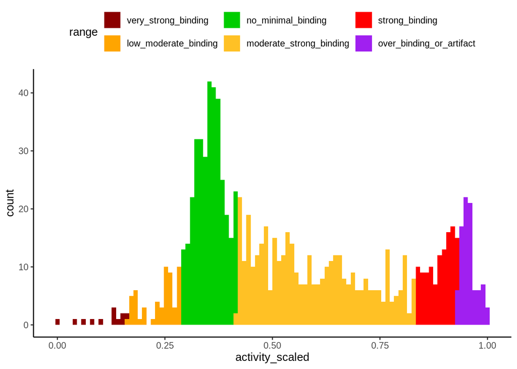

```r
ggplot(data = challenge_data_fp %>%
  filter(origin == "train") %>%
  select(activity_scaled, range),
       aes(x = activity_scaled, fill = range)) +
  geom_histogram(bins = 100) +
  scale_fill_manual(values = c("darkred", "orange", "green3", "goldenrod1", "red", "purple")) +
  theme_classic() +
  theme(
    legend.position = "top"
  )
```

Save scaled data to disk

```r
write_csv(x = challenge_data_fp %>%
  filter(origin == "train") %>%
  select(SMILES, activity_scaled),
          file = "/data/bioinf/projects/data/2022_deepFPlearn/input_datasets/tox24_challenge/tox24_challenge_train_scaled.csv")
```

Cluster fingerprints and colorize by range and/or test set.

The `M3C::tsne()` function requires the samples in the columns, and the features in the rows. So, we need to adjust our data.

Any duplicates for the fingerprint?

```r
challenge_data_fp_no_duplicates <- challenge_data_fp %>%
  filter(!duplicated(select(challenge_data_fp, starts_with("fp_"))))
challenge_data_fp_no_duplicates_train <- challenge_data_fp_no_duplicates %>%
  filter(origin == "train")
```

We need to discard the duplicated fingerprints for t-sne plotting. However, we maybe should include them in the model training

```r
# create an index for the rows and a mapping to SMILES to avoid having the SMILES as column names
index <- as.character(1:nrow(challenge_data_fp_no_duplicates))
mapping <- challenge_data_fp_no_duplicates$SMILES
names(mapping) <- index
# transpose dataframe
challenge_data_fp_long <- challenge_data_fp_no_duplicates %>%
  rowid_to_column("idx") %>%
  select(idx, starts_with("fp_")) %>%
  pivot_longer(cols = starts_with("fp_"), names_to = "feature", values_to = "value")
challenge_data_fp_wide <- challenge_data_fp_long %>%
  pivot_wider(names_from = "idx", values_from = "value")
```

Collect all information for TSNE plotting in an object

```r
info <- list()
info$mapping <- mapping
info$data <- challenge_data_fp_wide %>% select(-feature)
info$class <- challenge_data_fp_no_duplicates$range
info$dataset <- challenge_data_fp_no_duplicates$origin
info$activity <- challenge_data_fp_no_duplicates$activity
```

Now, we can run the t-SNE.

```
***t-SNE wrapper function***
```

```
running...
```

```
done.
```

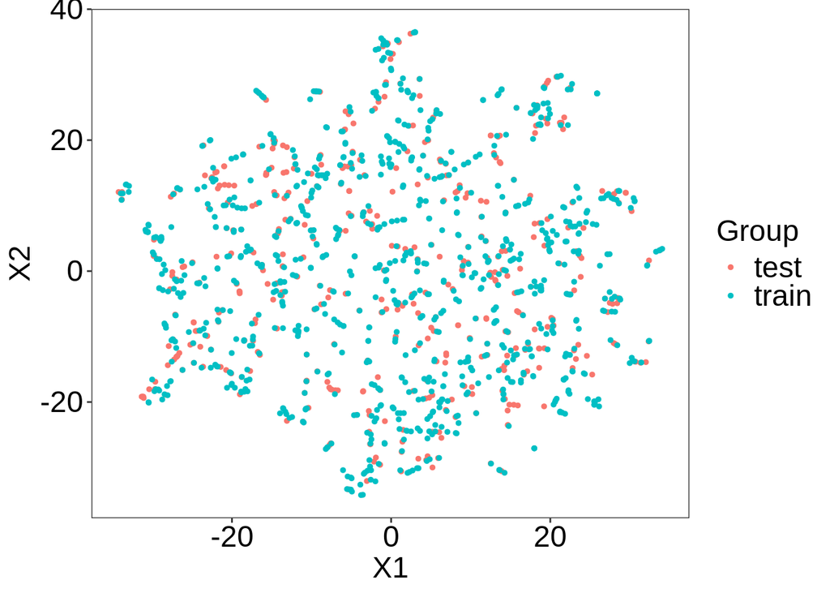

```r
# by dataset
tsne(mydata = info$data, labels = as.factor(info$dataset), dotsize = 1)
```

Nice!

```
***t-SNE wrapper function***
```

```
running...
```

```
done.
```

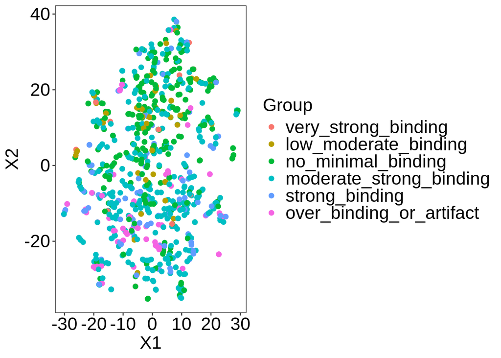

```r
index2 <- as.character(1:nrow(challenge_data_fp_no_duplicates_train))
mapping2 <- challenge_data_fp_no_duplicates_train$SMILES
names(mapping2) <- index2
# transpose dataframe
challenge_data_fp_long2 <- challenge_data_fp_no_duplicates_train %>%
  rowid_to_column("idx") %>%
  select(idx, starts_with("fp_")) %>%
  pivot_longer(cols = starts_with("fp_"), names_to = "feature", values_to = "value")
challenge_data_fp_wide2 <- challenge_data_fp_long2 %>%
  pivot_wider(names_from = "idx", values_from = "value")
info2 <- list()
info2$mapping <- mapping2
info2$data <- challenge_data_fp_wide2 %>% select(-feature)
info2$class <- challenge_data_fp_no_duplicates_train$range
info2$dataset <- challenge_data_fp_no_duplicates_train$origin
info2$activity <- challenge_data_fp_no_duplicates_train$activity
# by activity
tsne(mydata = info2$data, labels = as.factor(info2$class), dotsize = 2)
```